# Standard Errors and Confidence Intervals

9/24/2018

## Plan for today

- Calculating standard error in R
- Writing your own function in R
- The t distribution (`qt()` and `pt()`)
- Calculating confidence intervals in R
- Plotting error bars with `ggplot2`

## Calculating standard error in R

```r
head(diamonds, 10)
```

```
## # A tibble: 10 x 10
##    carat cut       color clarity depth table price     x     y     z
##    <dbl> <ord>     <ord> <ord>   <dbl> <dbl> <int> <dbl> <dbl> <dbl>
##  1 0.23  Ideal     E     SI2      61.5    55   326  3.95  3.98  2.43
##  2 0.21  Premium   E     SI1      59.8    61   326  3.89  3.84  2.31
##  3 0.23  Good      E     VS1      56.9    65   327  4.05  4.07  2.31
##  4 0.290 Premium   I     VS2      62.4    58   334  4.2   4.23  2.63
##  5 0.31  Good      J     SI2      63.3    58   335  4.34  4.35  2.75
##  6 0.24  Very Good J     VVS2     62.8    57   336  3.94  3.96  2.48
##  7 0.24  Very Good I     VVS1     62.3    57   336  3.95  3.98  2.47
##  8 0.26  Very Good H     SI1      61.9    55   337  4.07  4.11  2.53
##  9 0.22  Fair      E     VS2      65.1    61   337  3.87  3.78  2.49
## 10 0.23  Very Good H     VS1      59.4    61   338  4     4.05  2.39
```

## Calculating standard error in R

```r
head(diamonds, 1)
```

```
## # A tibble: 1 x 10
##   carat cut   color clarity depth table price     x     y     z
##   <dbl> <ord> <ord> <ord>   <dbl> <dbl> <int> <dbl> <dbl> <dbl>
## 1  0.23 Ideal E     SI2      61.5    55   326  3.95  3.98  2.43
```

```r
head(diamonds$price)
```

```
## [1] 326 326 327 334 335 336
```

```r
tail(diamonds$price)
```

```
## [1] 2757 2757 2757 2757 2757 2757
```

## Calculating standard error in R

```r
diamond_price <- diamonds$price

sd(diamond_price)
```

```
## [1] 3989.44
```

## Calculating standard error in R

```r
diamond_price <- diamonds$price

sd(diamond_price)
```

```
## [1] 3989.44
```

```r
se(diamond_price)
```

```
## Error in se(diamond_price): could not find function "se"
```

## Writing your own function in R

- To calculate the **standard error of the mean**…
- We need to take the sample standard deviation \(s\)
- And divide by the square root of the sample number \(n\)

\[SE = \frac{s}{\sqrt{n}}\]

## Writing your own function in R

- To calculate the **standard error of the mean**…
- We need to take the sample standard deviation \(s\)
- And divide by the square root of the sample number \(n\)

```r
36/2
```

```
## [1] 18
```

```r
sqrt(4)
```

```
## [1] 2
```

```r
36/sqrt(4)
```

```
## [1] 18
```

## Writing your own function in R

```r
sd(diamond_price)
```

```
## [1] 3989.44
```

## Writing your own function in R

```r
sd(diamond_price)
```

```
## [1] 3989.44
```

```r
length(diamond_price)
```

```
## [1] 53940
```

## Writing your own function in R

```r
sd(diamond_price)
```

```
## [1] 3989.44
```

```r
length(diamond_price)
```

```
## [1] 53940
```

```r
sd(diamond_price)/sqrt(length(diamond_price))
```

```
## [1] 17.17736
```

## Writing your own function in R

```r
cheer_up <- function(x) {
  print(paste("Wow,", x, "is so great!"))
}

cheer_up("Avalon")
```

```
## [1] "Wow, Avalon is so great!"
```

## Writing your own function in R

```r
cheer_up <- function(x) {
  print(paste("Wow,", x, "is so great!"))
}

cheer_up("Avalon")
```

```
## [1] "Wow, Avalon is so great!"
```

```r
cheer_up("Eric")
```

```
## [1] "Wow, Eric is so great!"
```

## Writing your own function in R

How would you write a function to calculate standard error?

## Writing your own function in R

```r
se <- function(x) {
  sd(x)/sqrt(length(x))
}
```

## Writing your own function in R

```r
se <- function(x) {
  sd(x)/sqrt(length(x))
}

se(diamond_price)
```

```
## [1] 17.17736
```

## Coding hack #1

## Coding hack #1

- Highlight a line of code and choose "Code > Extract Function"
- It will turn it into a function for you!

## The t-distribution

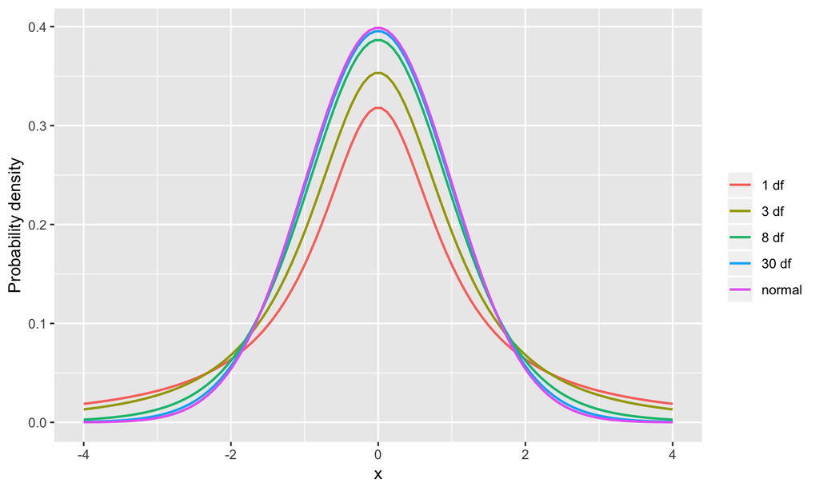

## The t-distribution

- All probability distributions in R have four related functions:
  - A density function that starts with `d`
  - A distribution function that starts with `p`
  - A quantile function that starts with a `q`
  - A random number function that starts with `r`

## The `*binom()` family of functions

- `dbinom()`, the density function — \(p[x = 5]\)?
- `pbinom()`, the distribution function — \(p[x \leq 5]\)?
- `qbinom()`, the quantile function — \(q[p = 0.62]\)?
- `rbinom()`, the random number generator

## The `*norm()` family of functions

- `dnorm()`, the density function — **don't use it!**
- `pnorm()`, the distribution function — \(p[x > 1.64]\)?
- `qnorm()`, the quantile function — \(q[p = 0.05]\)?
- `rnorm()`, the random number generator

## The `*t()` family of functions

- `dt(x, df)`, the density function
- `pt(q, df, lower.tail = T)`, the distribution function
- `qt(p, df, lower.tail = T)`, the quantile function
- `rt(n, df)`, the random number generator

## Calculating confidence intervals in R

\[\bar{Y} ± t_{\alpha,df}\textrm{SE}_{\bar{Y}}\]  
\[\alpha = \frac{1-CI}{2}\] \[df = n - 1\] \[SE = \frac{s}{\sqrt{n}}\]

## Calculating confidence intervals in R

```r
baby_snek = c(13, 15, 10, 17, 20, 9, 24, 18, 13, 12, 17, 16, 10, 21)
length(baby_snek)
```

```
## [1] 14
```

```r
t_snek <- qt(0.025, 14 - 1, lower.tail = F)
SE_snek <- se(baby_snek)
CI_snek <- t_snek*SE_snek
x_snek <- mean(baby_snek)
c(x_snek - CI_snek, x_snek + CI_snek)
```

```
## [1] 12.76899 17.94530
```

## Calculating confidence intervals in R

- Write a function that automatically calculates 95% CI!

\[\bar{Y} ± t_{\alpha,df}\textrm{SE}_{\bar{Y}}\]

## Calculating confidence intervals in R

- Write a function that automatically calculates 95% CI!

```r
CI <- function(x) {
  t_x <- qt(0.025, length(x)-1, lower.tail=F)
  SE_x <- sd(x)/sqrt(length(x))
  c(mean(x) - t_x*SE_x, mean(x) + t_x*SE_x)
}
CI(baby_snek)
```

```
## [1] 12.76899 17.94530
```

## Plotting error bars with `ggplot2`

[figure not shown]

## Plotting error bars with `ggplot2`

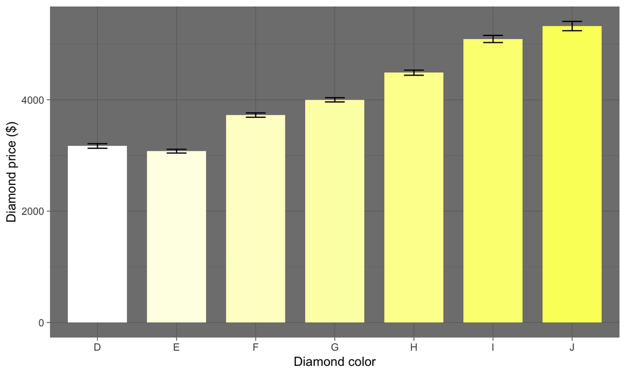

## Plotting error bars with `ggplot2`

```r
caratcake <- diamonds %>%
  group_by(color) %>%
  summarize(dollarbills = mean(price),
            dbills_SD = sd(price),
            dbills_SE = se(price),
            no_diamonds = length(price))
caratcake
```

```
## # A tibble: 7 x 5
##   color dollarbills dbills_SD dbills_SE no_diamonds
##   <ord>       <dbl>     <dbl>     <dbl>       <int>
## 1 D           3170.     3357.      40.8        6775
## 2 E           3077.     3344.      33.8        9797
## 3 F           3725.     3785.      38.7        9542
## 4 G           3999.     4051.      38.1       11292
## 5 H           4487.     4216.      46.3        8304
## 6 I           5092.     4722.      64.1        5422
## 7 J           5324.     4438.      83.8        2808
```

## Plotting error bars with `ggplot2`

```r
diagram <- ggplot(caratcake, aes(x = color,
                                 y = dollarbills,
                                 fill = color)) +
    geom_col(width = 0.75) +
    geom_errorbar(aes(ymin = dollarbills - dbills_SE,
                      ymax = dollarbills + dbills_SE),
                  width = 0.25) +
    labs(x = "Diamond color", y = "Diamond price ($)")
```

## Plotting error bars with `ggplot2`

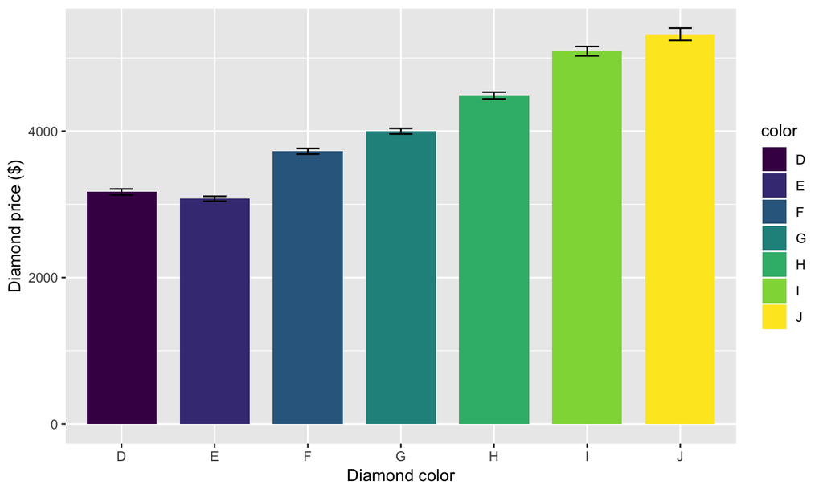

```r
diagram
```

## Plotting error bars with `ggplot2`

```r
caratcasserole <- diamonds %>%
  group_by(color) %>%
  summarize(dollarbills = mean(price),
            dbills_CI = qt(0.925, length(price)-1)*sd(price)/sqrt(length(price)),
            no_diamonds = length(price))
caratcasserole
```

```
## # A tibble: 7 x 4
##   color dollarbills dbills_CI no_diamonds
##   <ord>       <dbl>     <dbl>       <int>
## 1 D           3170.      58.7        6775
## 2 E           3077.      48.6        9797
## 3 F           3725.      55.8        9542
## 4 G           3999.      54.9       11292
## 5 H           4487.      66.6        8304
## 6 I           5092.      92.3        5422
## 7 J           5324.     121.         2808
```

## Plotting error bars with `ggplot2`

```r
diagram2 <- ggplot(caratcasserole, aes(x = color,
                                      y = dollarbills,
                                      fill = color)) +
    geom_col(width = 0.75) +
    geom_errorbar(aes(ymin = dollarbills - dbills_CI,
                      ymax = dollarbills + dbills_CI),
                  width = 0.25) +
    labs(x = "Diamond color", y = "Diamond price ($)")
```

## Plotting error bars with `ggplot2`

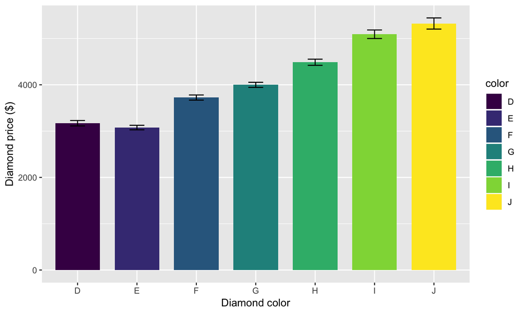

```r
diagram2
```